# `ntbox`: package installation notes

## Summary

In this document, we show how to install `ntbox` on different platforms (Windows, Mac OS, and Linux). As some functions of the package use compiled code, the user should have developer tools installed on the computer; once installed it is stright foward to install the package.

**note:`ntbox` works on R version >= 3.6**. We recommend version 4.0

## Windows

Install [`RTools`](https://cran.r-project.org/bin/windows/Rtools/)(https://cran.r-project.org/bin/windows/Rtools/).

> > > “`RTools` has a collection of resources for building packages for R under Microsoft Windows, or for building R itself (version 1.9.0 or later). The original collection was put together by Prof. Brian Ripley and Duncan Murdoch; it is currently maintained by Jeroen Ooms.”

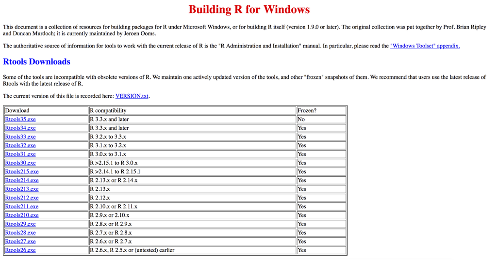

RTools web site

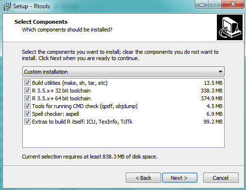

Rtool.exe

Ensuere to add RTools to systems path

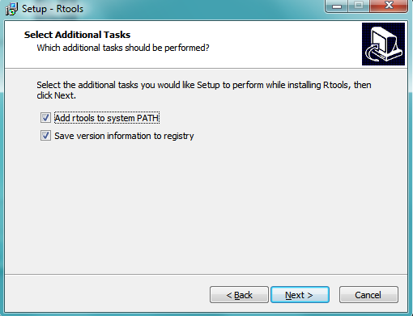

Install `pandoc` from

```bash
https://github.com/jgm/pandoc/releases/tag/2.9.2
```

## Linux

Install the R development package, usually called r-devel or r-base-dev.

Install the `C/C++` libraries that let R work as Geographic Information System ([GIS](https://en.wikipedia.org/wiki/Geographic_information_system))-

- [`gdal-devel`](http://www.gdal.org/) GDAL - Geospatial Data Abstraction Library. “GDAL is a translator library for raster and vector geospatial data formats that is released under an X/MIT style Open Source license by the Open Source Geospatial Foundation. As a library, it presents a single raster abstract data model and single vector abstract data model to the calling application for all supported formats. It also comes with a variety of useful command line utilities for data translation and processing.”
- [`geos-devel`](https://trac.osgeo.org/geos) Geometry Engine - Open Source. “GEOS (Geometry Engine - Open Source) is a C++ port of the Java Topology Suite (JTS). As such, it aims to contain the complete functionality of JTS in C++. This includes all the OpenGIS Simple Features for SQL spatial predicate functions and spatial operators, as well as specific JTS enhanced topology functions.”
- [`Proj4`](http://proj4.org/). “PROJ is a generic coordinate transformation software, that transforms geospatial coordinates from one coordinate reference system (CRS) to another. This includes cartographic projections as well as geodetic transformations”.

### Install and configure `java openjdk`

If you are using a [`fedora`](https://getfedora.org/) distribution you can

```bash
sudo yum install java-1.8.0-openjdk-devel
sudo yum install java-1.8.0-openjdk-headless
sudo /usr/bin/R CMD javareconf
```

This code installs the SIG libraries

```bash
sudo yum install gdal-devel proj-devel proj-epsg proj-nad geos-devel
```

Some other `C/C++` and `javascript` libraries

```bash
sudo yum install ncftp libxml2-devel libxslt v8-devel
sudo yum install mesa-libGL-devel mesa-libGLU-devel
sudo yum install libpng-devel libssl-devel
sudo yum install openssl-devel
sudo yum install libcurl-devel
```

Install `pandoc` from

```bash
https://github.com/jgm/pandoc/releases/tag/2.9.2
```

## Mac OS

On Mac, install the Xcode command line tools. Open terminal and type:

```bash
xcode-select --install
```

We highly recommend to have installed [`Homebrew`](https://brew.sh/); `Homebrew` gives the user an easy way to install development libraries …

> > > “`Homebrew` installs the stuff you need that Apple (or your Linux system) didn’t.”

To install `C/C++` Geographic Information System libraries via `homebrew` you just need to go to the terminal and type:

```bash
brew install geos gdal proj netcdf
```

The other `C/C++` and `javascript` libraries

```bash
brew install v8 libpng curl libxml2
```

Install `pandoc`

```bash
brew install pandoc
```

## Package installation

First install `devtools`

```r
if (!require('devtools'))
  install.packages('devtools')
```

Then load `devtools` and use the function `devtools::install_github`. `ntbox` is on continue development so the latest version of the package is on the author’s [`github`](https://github.com/luismurao/ntbox) repository (https://github.com/luismurao/ntbox)

```r
library(devtools)
devtools::install_github("luismurao/ntbox")
```

## Load the GUI of `ntbox`

Once `ntbox` is installed type the following commands on R:

```r
library(ntbox)
ntbox::run_ntbox()
```

The above will launch the Graphical User Interface (GUI) of `ntbox`

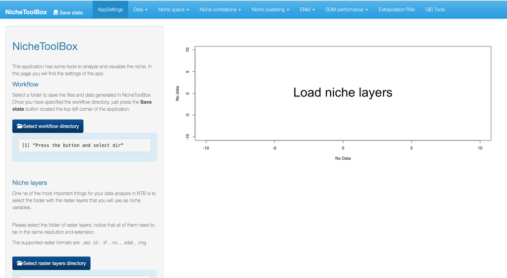

Graphical User Interface of `ntbox`